# Exploratory Data Analysis of COVID patients Metadata

Diego Maquieira Vidal (diego.maquieira01@estudiant.upf.edu) and Alberto Domingo Gómez (alberto.domingo01@estudiant.upf.edu)

2026-03-08

We will work with the publication [**Proteomic and Metabolomic Characterization of COVID-19 Patient Sera**](https://www.sciencedirect.com/science/article/pii/S0092867420306279)

# Exercise 1

Download and load Supplementary Table 1 (“Additional Demographical and Baseline Characteristics of COVID-19 Patients and Control Groups”) from the supplementary materials of the publication.

## Exercise 1.1

Reproduce Table 1 from the manuscript using the supplementary data. Match the reported summary statistics as closely as possible.

Briefly discuss any discrepancies between your results and the published table, and provide possible explanations.

```r
suppressMessages(suppressWarnings(invisible(if (!require("readxl")) {install.packages("readxl")})))
suppressMessages(suppressWarnings(invisible(if (!require("dplyr")) {install.packages("dplyr")})))
suppressMessages(suppressWarnings(invisible(if (!require("tidyr")) {install.packages("tidyr")})))
suppressMessages(suppressWarnings(invisible(if (!require("knitr")) {install.packages("knitr")})))
suppressMessages(suppressWarnings(invisible(if (!require("kableExtra")) {install.packages("kableExtra")})))
suppressMessages(suppressWarnings(invisible(if (!require("ggplot2")) {install.packages("ggplot2")})))
suppressMessages(suppressWarnings(invisible(if (!require("corrplot")) {install.packages("corrplot")})))
suppressMessages(suppressWarnings(invisible(if (!require("purrr")) {install.packages("purrr")})))
suppressMessages(suppressWarnings(invisible(if (!require("ggpubr")) {install.packages("ggpubr")})))
suppressMessages(suppressWarnings(invisible(if (!require("rstatix")) {install.packages("rstatix")})))
suppressMessages(suppressWarnings(invisible(if (!require("pheatmap")) {install.packages("pheatmap")})))
suppressMessages(suppressWarnings(invisible(if (!require("grid")) {install.packages("grid")})))
suppressMessages(suppressWarnings(invisible(if (!require("RColorBrewer")) {install.packages("RColorBrewer")})))

# Libraries preparation
suppressMessages(invisible(library(readxl)))
suppressMessages(invisible(library(dplyr)))
suppressMessages(invisible(library(tidyr)))
suppressMessages(invisible(library(knitr)))
suppressMessages(invisible(library(kableExtra)))
suppressMessages(invisible(library(ggplot2)))
suppressMessages(invisible(library(corrplot)))
suppressMessages(invisible(library(purrr)))
suppressMessages(invisible(library(ggpubr)))
suppressMessages(invisible(library(rstatix)))
suppressMessages(invisible(library(pheatmap)))
```

```r
# Load and Preprocess Clinical Metadata
# Define the named vector for all columns to ensure safe importing
st1_types <- c(
  "Patient ID a" = "text", "Proteomics" = "text", "MS ID b" = "text",
  "MSRep ID c" = "text", "Group d" = "numeric", "COVID-19 patients corhort" = "text",
  "Metabolomics analysis" = "text", "Metabolomics ID e" = "text", "Onset date f" = "date",
  "Admission date" = "date", "Date of progression to severe state" = "date",
  "Sampling date for metabolomics" = "date", "Sampling date for proteomics" = "date",
  "Discharge Date" = "date", "Sex g" = "numeric", "Age (year)" = "numeric",
  "BMI h" = "numeric", "Test date...18" = "date", "WBC count, ×109/L" = "numeric",
  "Lymphocyte count, ×109/L" = "numeric", "Monocyte count, ×109/L" = "numeric",
  "Platelet count, ×109/L" = "numeric", "Test date...23" = "date", "CRP i, mg/L" = "numeric",
  "ALT j,  U/L" = "numeric", "AST k, U/L" = "numeric", "GGT l, U/L" = "numeric",
  "TBIL m, μmol/L" = "numeric", "DBIL n, μmol/L" = "numeric", "Creatinine, μmol/L" = "numeric",
  "Glucose, mmol/L" = "numeric"
)

# Load the data
suppressWarnings(suppressMessages(df_clinical <- read_excel("data/ts_1_data.xlsx",
                          sheet = "Clinical_information",
                          col_types = st1_types)))

# Calculate time intervals and assign descriptive group names
df_clinical <- df_clinical %>%
  mutate(
    # Calculate days. Adding 1 to include both start and end days
    days_onset_to_adm = as.numeric(difftime(`Admission date`, `Onset date f`, units = "days")) + 1,
    days_adm_to_severe = as.numeric(difftime(`Date of progression to severe state`, `Admission date`, units = "days")) + 1,

    # Map numeric groups to descriptive factors
    Group_Label = case_when(
      `Group d` == 0 ~ "Healthy Control",
      `Group d` == 1 ~ "Non-COVID-19",
      `Group d` == 2 ~ "Non-Severe COVID-19",
      `Group d` == 3 ~ "Severe COVID-19"
    )
  )

# Summarize Clinical Characteristics
# Helper function to format range safely
get_range <- function(x) {
  if(all(is.na(x))) return(NA_character_)
  paste0(round(min(x, na.rm = TRUE), 1), " - ", round(max(x, na.rm = TRUE), 1))
}

# Create the "COVID-19 Total" subset
covid_total <- df_clinical %>%
  filter(`Group d` %in% c(2, 3)) %>%
  mutate(Group_Label = "COVID-19 Total")

# Bind them together and set factor levels for correct column order later
combined_clinical <- bind_rows(df_clinical, covid_total) %>%
  mutate(Group_Label = factor(Group_Label, levels = c(
    "Healthy Control", "Non-COVID-19", "COVID-19 Total", "Non-Severe COVID-19", "Severe COVID-19"
  )))

# Calculate all summary statistics in one elegant pipeline
summary_stats <- combined_clinical %>%
  group_by(Group_Label) %>%
  summarise(
    # Counts
    N = n(),
    n_male = sum(`Sex g` == 1, na.rm = TRUE),
    n_female = sum(`Sex g` == 0, na.rm = TRUE),
    per_male = (n_male / N) * 100,
    per_female = (n_female / N) * 100,

    # Age & BMI
    across(c(`Age (year)`, `BMI h`, days_onset_to_adm, days_adm_to_severe),
           list(
             mean = ~mean(., na.rm = TRUE),
             sd = ~sd(., na.rm = TRUE),
             median = ~median(., na.rm = TRUE),
             iqr = ~IQR(., na.rm = TRUE),
             range = ~get_range(.)
           ),
           .names = "{.col}_{.fn}")
  ) %>%
  # Round all numeric values to 2 decimal places
  mutate(across(where(is.numeric), ~ round(., 2)))

# Format and Render Table 1
formatted_table <- summary_stats %>%
  dplyr::mutate(
    Male = base::sprintf("%d (%.1f%%)", n_male, per_male),
    Female = base::sprintf("%d (%.1f%%)", n_female, per_female),

    `Age Mean ± SD`  = base::sprintf("%.2f ± %.2f", `Age (year)_mean`, `Age (year)_sd`),
    `Age Median(IQR)` = base::sprintf("%.2f ± %.2f", `Age (year)_median`, `Age (year)_iqr`),
    `Age Range` = `Age (year)_range`,

    `BMI Mean ± SD`  = base::sprintf("%.2f ± %.2f", `BMI h_mean`, `BMI h_sd`),
    `BMI Median(IQR)` = base::sprintf("%.2f ± %.2f", `BMI h_median`, `BMI h_iqr`),
    `BMI Range` = `BMI h_range`,

    `Onset Mean ± SD`  = base::sprintf("%.2f ± %.2f", days_onset_to_adm_mean, days_onset_to_adm_sd),
    `Onset Median(IQR)` = base::sprintf("%.2f ± %.2f", days_onset_to_adm_median, days_onset_to_adm_iqr),
    `Onset Range` = days_onset_to_adm_range,

    `Severe Mean ± SD`  = base::sprintf("%.2f ± %.2f", days_adm_to_severe_mean, days_adm_to_severe_sd),
    `Severe Median(IQR)` = base::sprintf("%.2f ± %.2f", days_adm_to_severe_median, days_adm_to_severe_iqr),
    `Severe Range` = days_adm_to_severe_range
  ) %>%
  dplyr::select(
    Group_Label, N,
    Male, Female,
    `Age Mean ± SD`, `Age Median(IQR)`, `Age Range`,
    `BMI Mean ± SD`, `BMI Median(IQR)`, `BMI Range`,
    `Onset Mean ± SD`, `Onset Median(IQR)`, `Onset Range`,
    `Severe Mean ± SD`, `Severe Median(IQR)`, `Severe Range`
  ) %>%
  dplyr::mutate(Group_Label = base::paste0(Group_Label, " (N = ", N, ")")) %>%
  dplyr::select(-N)

final_table <- formatted_table %>%
  tidyr::pivot_longer(cols = -Group_Label, names_to = "Metric_Raw", values_to = "Value") %>%
  tidyr::pivot_wider(names_from = Group_Label, values_from = Value) %>%
  dplyr::mutate(Variables = base::gsub("^(Age|BMI|Onset|Severe) ", "", Metric_Raw)) %>%
  dplyr::select(Variables, tidyselect::everything(), -Metric_Raw)

final_table <- final_table %>%
  dplyr::mutate(
    dplyr::across(base::c(2, 3), ~ base::ifelse(dplyr::row_number() >= 9 & dplyr::row_number() <= 14, "-", .)),
    dplyr::across(base::c(4, 5), ~ base::ifelse(dplyr::row_number() >= 12 & dplyr::row_number() <= 14, "-", .))
  )

final_table %>%
  kableExtra::kbl(booktabs = TRUE,
      caption = "Tabla 1. Características Clínicas y de Laboratorio de los Pacientes") %>%
  kableExtra::kable_classic(full_width = FALSE, html_font = "Arial") %>%
  kableExtra::pack_rows("Sex - no. (%)", 1, 2) %>%
  kableExtra::pack_rows("Age - year", 3, 5) %>%
  kableExtra::pack_rows("BMI, kg/m²", 6, 8) %>%
  kableExtra::pack_rows("Time from Onset to Admission, Days", 9, 11) %>%
  kableExtra::pack_rows("Time from Admission to Severe, Days", 12, 14) %>%
  kableExtra::row_spec(0, bold = TRUE) %>%
  kableExtra::column_spec(1, bold = TRUE, width = "10cm") %>%
  kableExtra::kable_styling(latex_options = base::c("hold_position", "scale_down"))
```

Tabla 1. Características Clínicas y de Laboratorio de los Pacientes

Variables

Healthy Control (N = 28)

Non-COVID-19 (N = 25)

COVID-19 Total (N = 65)

Non-Severe COVID-19 (N = 37)

Severe COVID-19 (N = 28)

**Sex - no. (%)**

Male

21 (75.0%)

17 (68.0%)

39 (60.0%)

23 (62.2%)

16 (57.1%)

Female

7 (25.0%)

8 (32.0%)

26 (40.0%)

14 (37.8%)

12 (42.9%)

**Age - year**

Mean ± SD

44.36 ± 8.26

49.20 ± 14.04

48.06 ± 13.86

42.95 ± 12.47

54.82 ± 12.82

Median(IQR)

45.00 ± 13.00

53.00 ± 23.00

47.00 ± 19.00

43.00 ± 15.00

55.00 ± 17.25

Range

28 - 57

23 - 67

18 - 77

18 - 70

30 - 77

**BMI, kg/m²**

Mean ± SD

24.44 ± 2.71

23.49 ± 2.68

24.88 ± 2.98

24.45 ± 3.21

25.51 ± 2.52

Median(IQR)

24.22 ± 3.63

24.69 ± 4.25

24.74 ± 4.29

24.22 ± 4.88

24.91 ± 2.97

Range

19.9 - 32.9

19.1 - 27.4

18.9 - 31.3

18.9 - 30.7

21.1 - 31.3

**Time from Onset to Admission, Days**

Mean ± SD

6.00 ± 4.42

4.59 ± 3.17

7.86 ± 5.17

Median(IQR)

4.00 ± 6.00

4.00 ± 2.00

8.50 ± 8.00

Range

1 - 24

1 - 15

1 - 24

**Time from Admission to Severe, Days**

Mean ± SD

2.39 ± 1.66

Median(IQR)

2.00 ± 2.25

Range

0 - 7

The procedure was able to recreate the vast majority of the table, and the values mostly coincide. However, at th Non-Severe COVID-19 patients group, two individuals assigned as males in the paper were assigned as females in this markdown. Hence, slight differences are appreciated in the descriptive statistics that involve this group. Nevertheless, the following analysis have the same number of individuals in both paper and this work. Therefore, it seems that the problem has been given in the paper analysis, but only in the creation of this table.

## Exercise 1.2

Perform an exploratory data analysis (EDA) of the dataset. At a minimum, include:

- Descriptive statistics for key variables
- Appropriate visualizations (e.g. distributions, group comparisons)
- A brief written summary of notable patterns, anomalies, or data quality issues

Descriptive statistics

```r
# Ungroup, filter, and select columns
df_labs <- combined_clinical %>%
  ungroup() %>%
  filter(Group_Label != "Healthy Control") %>%
  select(
    Group_Label,
    WBC = `WBC count, ×109/L`,
    Lymphocyte = `Lymphocyte count, ×109/L`,
    Monocyte = `Monocyte count, ×109/L`,
    Platelet = `Platelet count, ×109/L`,
    CRP = `CRP i, mg/L`,
    ALT = `ALT j,  U/L`,
    AST = `AST k, U/L`,
    GGT = `GGT l, U/L`,
    TBIL = `TBIL m, μmol/L`,
    DBIL = `DBIL n, μmol/L`,
    Creatinine = `Creatinine, μmol/L`,
    Glucose = `Glucose, mmol/L`
  )

# Calculate raw summary statistics
summary_labs <- df_labs %>%
  group_by(Group_Label) %>%
  summarise(
    N = n(),
    across(where(is.numeric),
           list(
             mean = ~mean(., na.rm = TRUE),
             sd = ~sd(., na.rm = TRUE),
             median = ~median(., na.rm = TRUE),
             iqr = ~IQR(., na.rm = TRUE),
             range = ~get_range(.)
           ),
           .names = "{.col}_{.fn}")
  )

# Pivot, Format, and Reshape
final_lab_table <- summary_labs %>%
  pivot_longer(
    cols = -c(Group_Label, N),
    names_to = c("Parameter", ".value"),
    names_sep = "_"
  ) %>%
  mutate(
    `Mean ± SD` = sprintf("%.2f ± %.2f", mean, sd),
    `Median (IQR)` = sprintf("%.2f (%.2f)", median, iqr),
    `Range` = range
  ) %>%
  select(Group_Label, N, Parameter, `Mean ± SD`, `Median (IQR)`, Range) %>%
  pivot_longer(cols = c(`Mean ± SD`, `Median (IQR)`, Range), names_to = "Metric", values_to = "Value") %>%
  mutate(
    Group_Label = paste0(Group_Label, "\n(N = ", N, ")")
  ) %>%
  select(-N) %>%
  pivot_wider(names_from = Group_Label, values_from = Value)

# Filter and Sort
param_order <- c("WBC", "Lymphocyte", "Monocyte", "Platelet",
                 "CRP", "ALT", "AST", "GGT",
                 "TBIL", "DBIL", "Creatinine", "Glucose")

final_lab_table <- final_lab_table %>%
  mutate(
    Parameter = factor(Parameter, levels = param_order),
    Metric = factor(Metric, levels = c("Mean ± SD", "Median (IQR)", "Range"))
  ) %>%
  filter(!is.na(Parameter)) %>%
  arrange(Parameter, Metric) %>%
  select(-Parameter)

# Render with kableExtra
final_lab_table %>%
  kbl(booktabs = TRUE,
      align = c("l", rep("c", 4)),
      caption = "Table 2. Laboratory and Biochemical Parameters of the Patients") %>%
  kable_classic(full_width = FALSE, html_font = "Arial") %>%

  pack_rows("WBC count, ×109/L", 1, 3) %>%
  pack_rows("Lymphocyte count, ×109/L", 4, 6) %>%
  pack_rows("Monocyte count, ×109/L", 7, 9) %>%
  pack_rows("Platelet count, ×109/L", 10, 12) %>%
  pack_rows("CRP, mg/L", 13, 15) %>%
  pack_rows("ALT, U/L", 16, 18) %>%
  pack_rows("AST, U/L", 19, 21) %>%
  pack_rows("GGT, U/L", 22, 24) %>%
  pack_rows("TBIL, μmol/L", 25, 27) %>%
  pack_rows("DBIL, μmol/L", 28, 30) %>%
  pack_rows("Creatinine, μmol/L", 31, 33) %>%
  pack_rows("Glucose, mmol/L", 34, 36) %>%

  row_spec(0, bold = TRUE) %>%
  column_spec(1, bold = FALSE, width = "4cm") %>%
  kable_styling(latex_options = c("hold_position", "scale_down"))
```

Table 2. Laboratory and Biochemical Parameters of the Patients

| Metric | Non-COVID-19 (N = 25) | COVID-19 Total (N = 65) | Non-Severe COVID-19 (N = 37) | Severe COVID-19 (N = 28) |
| --- | --- | --- | --- | --- |
| **WBC count, ×109/L** |  |  |  |  |
| Mean ± SD | 8.48 ± 4.22 | 6.32 ± 3.09 | 5.88 ± 2.23 | 6.90 ± 3.93 |
| Median (IQR) | 7.50 (3.80) | 5.71 (2.20) | 5.24 (2.44) | 6.11 (2.49) |
| Range | 3.3 - 24.2 | 1.9 - 23.6 | 3 - 13.3 | 1.9 - 23.6 |
| **Lymphocyte count, ×109/L** |  |  |  |  |
| Mean ± SD | 1.27 ± 0.90 | 1.25 ± 0.60 | 1.55 ± 0.51 | 0.85 ± 0.47 |
| Median (IQR) | 0.90 (0.90) | 1.20 (0.83) | 1.48 (0.53) | 0.74 (0.37) |
| Range | 0.2 - 4.1 | 0.2 - 2.7 | 0.7 - 2.7 | 0.2 - 2.6 |
| **Monocyte count, ×109/L** |  |  |  |  |
| Mean ± SD | 0.52 ± 0.21 | 0.47 ± 0.20 | 0.51 ± 0.22 | 0.41 ± 0.16 |
| Median (IQR) | 0.50 (0.40) | 0.42 (0.26) | 0.43 (0.24) | 0.42 (0.26) |
| Range | 0.1 - 0.9 | 0.1 - 1.2 | 0.2 - 1.2 | 0.1 - 0.7 |
| **Platelet count, ×109/L** |  |  |  |  |
| Mean ± SD | 192.52 ± 62.36 | 196.80 ± 56.62 | 207.43 ± 49.96 | 182.75 ± 62.53 |
| Median (IQR) | 208.00 (59.00) | 198.00 (73.00) | 205.00 (46.00) | 167.50 (111.75) |
| Range | 37 - 332 | 76 - 334 | 76 - 334 | 112 - 301 |
| **CRP, mg/L** |  |  |  |  |
| Mean ± SD | 58.38 ± 82.17 | 25.18 ± 37.08 | 13.20 ± 21.07 | 41.01 ± 47.03 |
| Median (IQR) | 19.60 (67.38) | 12.46 (27.46) | 4.80 (14.90) | 25.35 (44.89) |
| Range | 1 - 299.7 | 0.1 - 185 | 0.1 - 89.9 | 1.3 - 185 |
| **ALT, U/L** |  |  |  |  |
| Mean ± SD | 65.16 ± 160.59 | 28.42 ± 16.55 | 25.83 ± 12.89 | 31.84 ± 20.15 |
| Median (IQR) | 27.00 (44.00) | 22.00 (17.00) | 21.70 (13.80) | 26.05 (17.67) |
| Range | 7 - 824 | 9.5 - 97 | 9.5 - 67 | 9.5 - 97 |
| **AST, U/L** |  |  |  |  |
| Mean ± SD | 72.80 ± 147.59 | 29.95 ± 15.16 | 24.76 ± 6.35 | 36.82 ± 20.12 |
| Median (IQR) | 25.00 (27.00) | 26.00 (10.00) | 23.00 (9.00) | 28.50 (19.75) |
| Range | 10 - 743 | 13 - 85 | 13 - 41 | 13 - 85 |
| **GGT, U/L** |  |  |  |  |
| Mean ± SD | 52.92 ± 59.41 | 34.46 ± 21.57 | 30.95 ± 21.29 | 39.11 ± 21.43 |
| Median (IQR) | 35.00 (38.00) | 26.00 (28.00) | 23.00 (26.00) | 32.50 (29.25) |
| Range | 9 - 264 | 10 - 108 | 10 - 108 | 14 - 78 |
| **TBIL, μmol/L** |  |  |  |  |
| Mean ± SD | 35.42 ± 81.26 | 14.50 ± 8.00 | 13.32 ± 8.00 | 16.05 ± 7.87 |
| Median (IQR) | 14.90 (7.70) | 12.10 (9.80) | 11.20 (8.40) | 15.35 (9.20) |
| Range | 3.8 - 403.4 | 3.4 - 36.5 | 3.4 - 36.5 | 5.3 - 36.4 |
| **DBIL, μmol/L** |  |  |  |  |
| Mean ± SD | 18.02 ± 51.44 | 5.56 ± 3.56 | 5.00 ± 3.40 | 6.31 ± 3.68 |
| Median (IQR) | 4.90 (2.60) | 4.70 (3.90) | 4.00 (3.10) | 5.60 (3.92) |
| Range | 2.2 - 254.4 | 0.8 - 17.9 | 0.8 - 16.2 | 1.5 - 17.9 |
| **Creatinine, μmol/L** |  |  |  |  |
| Mean ± SD | 75.76 ± 32.07 | 84.75 ± 36.94 | 78.59 ± 14.91 | 92.89 ± 53.08 |
| Median (IQR) | 68.00 (29.00) | 78.00 (22.00) | 80.00 (22.00) | 77.00 (21.75) |
| Range | 4 - 170 | 55 - 335 | 55 - 110 | 56 - 335 |
| **Glucose, mmol/L** |  |  |  |  |
| Mean ± SD | 5.67 ± 1.26 | 8.18 ± 4.02 | 7.09 ± 2.79 | 9.63 ± 4.91 |
| Median (IQR) | 5.58 (1.09) | 7.31 (3.09) | 6.19 (2.61) | 8.05 (2.29) |
| Range | 3.6 - 10.5 | 4.5 - 25.6 | 4.5 - 18 | 4.6 - 25.6 |

Study of data distribution

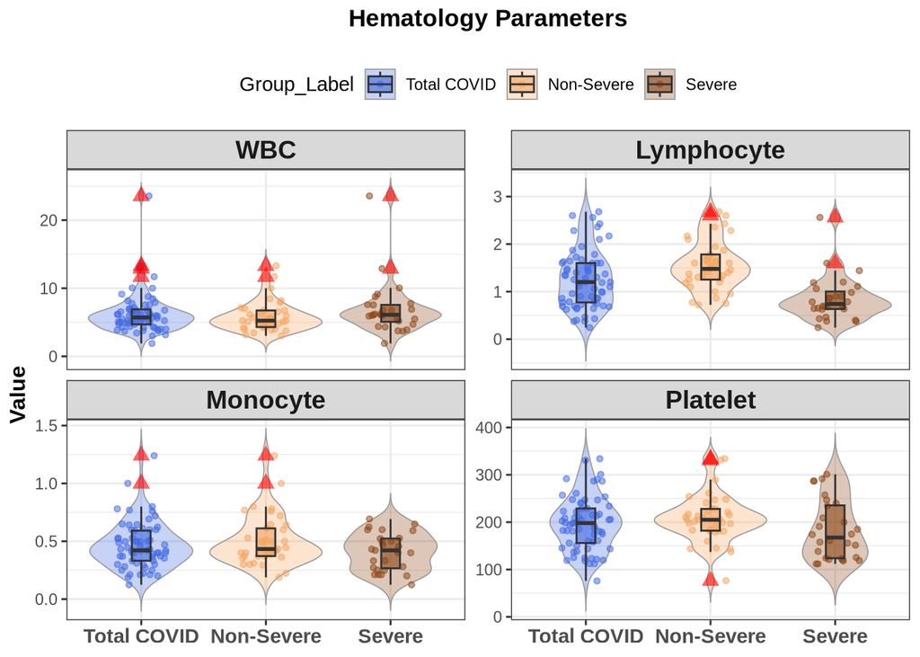

```r
# Exploratory Data Analysis of Clinical Parameters
# Data Preparation
param_order <- c("WBC", "Lymphocyte", "Monocyte", "Platelet",
                 "CRP", "ALT", "AST", "GGT",
                 "TBIL", "DBIL", "Creatinine", "Glucose")

# Prepare the dataframe for plotting
df_plot_covid <- df_clinical %>%
  # Combine groups 2 and 3 to create group 5 (Total)
  bind_rows(df_clinical %>% filter(`Group d` %in% 2:3) %>% mutate(`Group d` = 5)) %>%
  filter(`Group d` %in% c(2, 3, 5)) %>%
  mutate(
    Group_Label = case_when(
      `Group d` == 2 ~ "Non-Severe",
      `Group d` == 3 ~ "Severe",
      `Group d` == 5 ~ "Total COVID"
    ),
    # Order the groups: Total first, then Non-Severe, then Severe
    Group_Label = factor(Group_Label, levels = c("Total COVID", "Non-Severe", "Severe"))
  ) %>%
  # Rename columns for cleaner plot labels
  select(Group_Label,
         WBC = `WBC count, ×109/L`,
         Lymphocyte = `Lymphocyte count, ×109/L`,
         Monocyte = `Monocyte count, ×109/L`,
         Platelet = `Platelet count, ×109/L`,
         CRP = `CRP i, mg/L`,
         ALT = `ALT j,  U/L`,
         AST = `AST k, U/L`,
         GGT = `GGT l, U/L`,
         TBIL = `TBIL m, μmol/L`,
         DBIL = `DBIL n, μmol/L`,
         Creatinine = `Creatinine, μmol/L`,
         Glucose = `Glucose, mmol/L`) %>%
  pivot_longer(cols = -Group_Label, names_to = "Parameter", values_to = "Value") %>%
  mutate(Parameter = factor(Parameter, levels = param_order))

# Define Parameter Groups
vars_part1 <- c("WBC", "Lymphocyte", "Monocyte", "Platelet")
vars_part2 <- c("CRP", "ALT", "AST", "GGT")
vars_part3 <- c("TBIL", "DBIL", "Creatinine", "Glucose")

# Plotting Function
create_violin_plot <- function(data, param_list, plot_title) {

  subset_data <- data %>%
    filter(Parameter %in% param_list) %>%
    mutate(Parameter = factor(Parameter, levels = param_list))

  ggplot(subset_data, aes(x = Group_Label, y = Value, fill = Group_Label)) +
    geom_violin(trim = FALSE, alpha = 0.3, color = "grey60", linewidth = 0.3) +
    geom_jitter(aes(color = Group_Label), width = 0.2, size = 1.2, alpha = 0.5) +
    geom_boxplot(width = 0.15, outlier.colour = "red", outlier.shape = 17,
                 outlier.size = 3, alpha = 0.6) +
    facet_wrap(~ Parameter, scales = "free_y", ncol = 2) +
    # Using the custom color palette established in previous exercises
    scale_fill_manual(values = c("Total COVID" = "#4169E1", "Non-Severe" = "#F4A460", "Severe" = "#8B4513")) +
    scale_color_manual(values = c("Total COVID" = "#4169E1", "Non-Severe" = "#F4A460", "Severe" = "#8B4513")) +
    theme_bw() +
    labs(title = plot_title, x = NULL, y = "Value") +
    theme(
      legend.position = "top",
      strip.text = element_text(face = "bold", size = 14),
      axis.text.x = element_text(size = 11, face = "bold"),
      axis.title.y = element_text(size = 12, face = "bold"),
      plot.title = element_text(hjust = 0.5, face = "bold", margin = ggplot2::margin(b = 15))
    )
}

# Generate Plots
p1 <- create_violin_plot(df_plot_covid, vars_part1, "Hematology Parameters")
p2 <- create_violin_plot(df_plot_covid, vars_part2, "Inflammation & Liver Enzymes")
p3 <- create_violin_plot(df_plot_covid, vars_part3, "Bilirubin, Kidney & Glucose")

p1
```

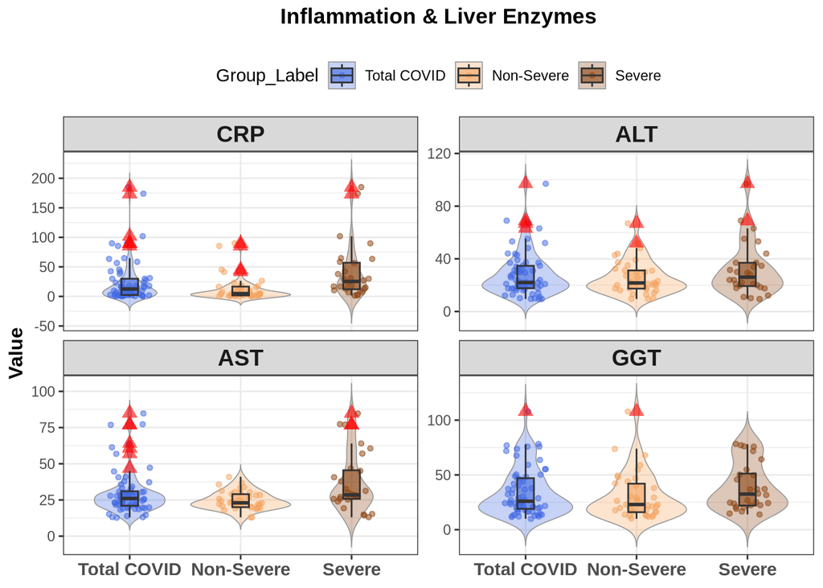

```r
p2
```

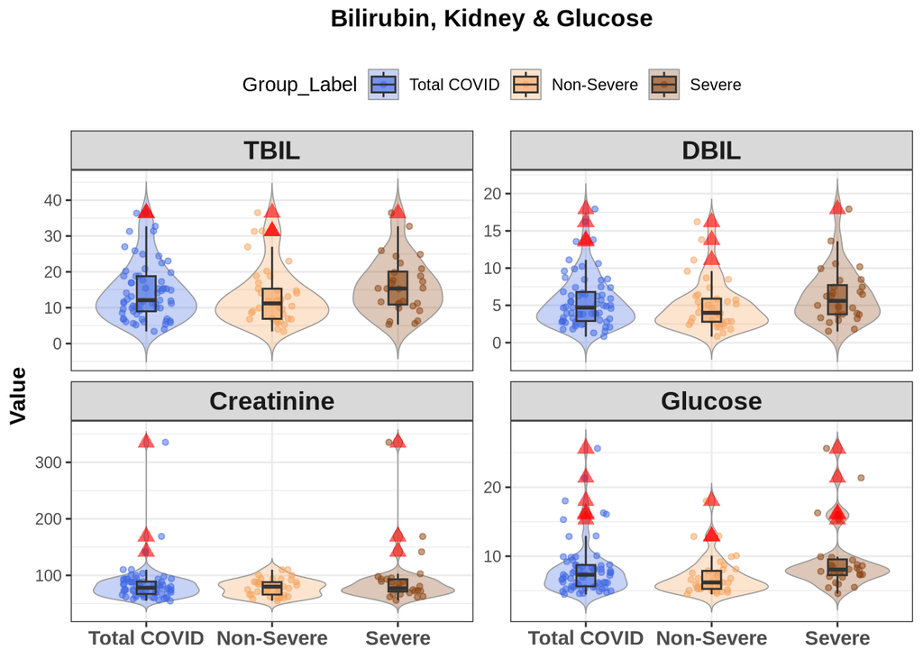

```r
p3
```

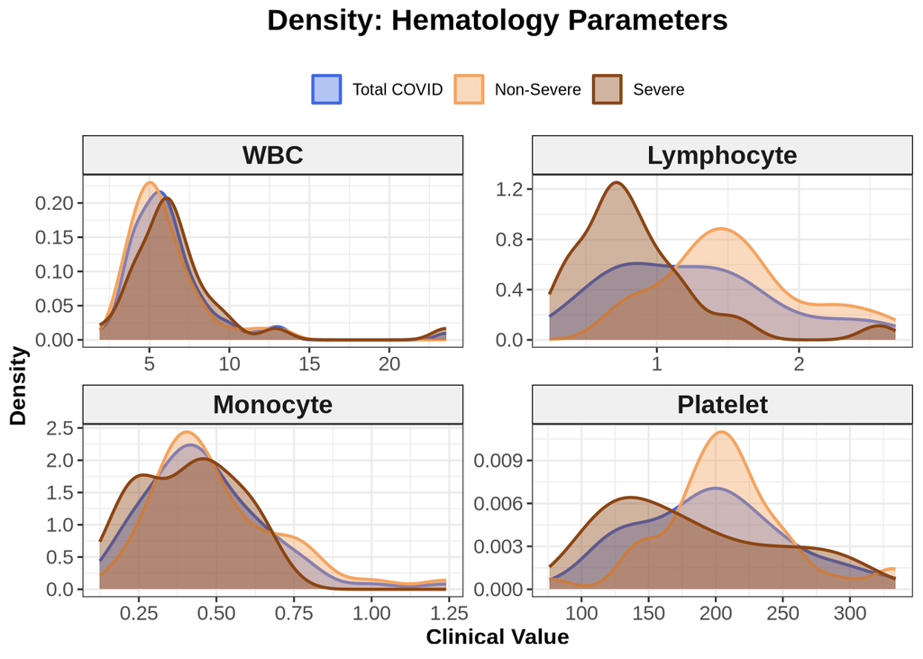

```r
# Plotting Function for Density Plots
create_density_plot <- function(data, param_list, plot_title) {

  # Filter and order the data
  subset_data <- data %>%
    filter(Parameter %in% param_list) %>%
    mutate(Parameter = factor(Parameter, levels = param_list))

  # Build the density plot
  ggplot(subset_data, aes(x = Value, fill = Group_Label, color = Group_Label)) +
    geom_density(alpha = 0.4, linewidth = 0.8) +
    facet_wrap(~ Parameter, scales = "free", ncol = 2) +
    scale_fill_manual(values = c("Total COVID" = "#4169E1", "Non-Severe" = "#F4A460", "Severe" = "#8B4513")) +
    scale_color_manual(values = c("Total COVID" = "#4169E1", "Non-Severe" = "#F4A460", "Severe" = "#8B4513")) +

    # Formatting and aesthetics
    theme_bw() +
    labs(
      title = plot_title,
      x = "Clinical Value",
      y = "Density"
    ) +
    theme(
      legend.position = "top",
      legend.title = element_blank(),
      strip.text = element_text(face = "bold", size = 14),
      axis.text = element_text(size = 11),
      axis.title = element_text(size = 12, face = "bold"),
      plot.title = element_text(hjust = 0.5, face = "bold", size = 16, margin = ggplot2::margin(b = 15)),
      strip.background = element_rect(fill = "#f0f0f0", color = "black")
    )
}

# Generate the Density Plots
p_dens1 <- create_density_plot(df_plot_covid, vars_part1, "Density: Hematology Parameters")
p_dens2 <- create_density_plot(df_plot_covid, vars_part2, "Density: Inflammation & Liver Enzymes")
p_dens3 <- create_density_plot(df_plot_covid, vars_part3, "Density: Bilirubin, Kidney & Glucose")

p_dens1
```

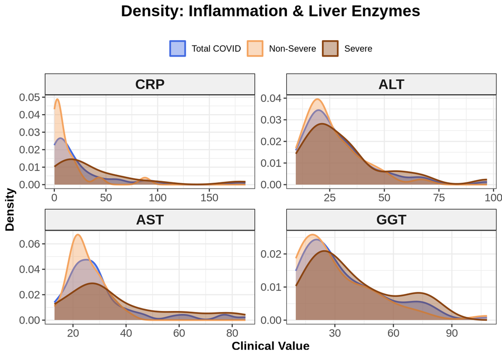

```r
p_dens2
```

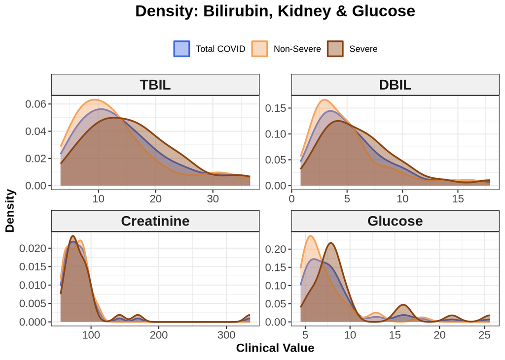

```r
p_dens3
```

Correlation study

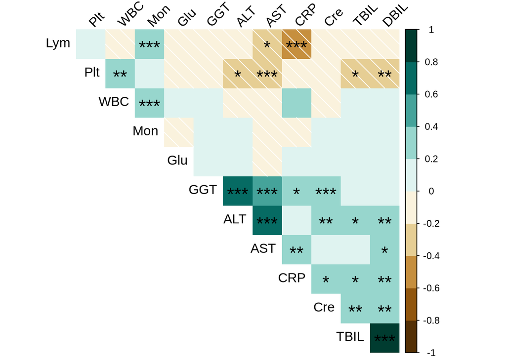

```r
# Prepare the numeric data
df_corr <- combined_clinical %>%
  filter(Group_Label != "COVID-19 Total") %>%
  select(WBC = `WBC count, ×109/L`, Lym = `Lymphocyte count, ×109/L`,
         Mon = `Monocyte count, ×109/L`, Plt = `Platelet count, ×109/L`,
         CRP = `CRP i, mg/L`, ALT = `ALT j,  U/L`, AST = `AST k, U/L`,
         GGT = `GGT l, U/L`, TBIL = `TBIL m, μmol/L`, DBIL = `DBIL n, μmol/L`,
         Cre = `Creatinine, μmol/L`, Glu = `Glucose, mmol/L`) %>%
  mutate(across(everything(), as.numeric))

# Calculate Spearman correlation and P-values
cor_matrix <- cor(df_corr, use = "pairwise.complete.obs", method = "spearman")
res_p <- suppressWarnings(cor.mtest(df_corr, conf.level = 0.95, method = "spearman"))
p_matrix <- res_p$p


par(mar = c(1, 1, 1, 1))

corrplot(cor_matrix,
         method = "shade",
         type = "upper",
         order = "hclust",

         p.mat = p_matrix,
         insig = "label_sig",
         sig.level = c(0.001, 0.01, 0.05),
         pch.cex = 1.5,
         pch.col = "black",

         tl.col = "black",
         tl.srt = 45,
         tl.cex = 1.1,

         addCoef.col = NULL,

         diag = FALSE,
         col = COL2('BrBG', 10)
)
```

The negative correlation between platelets and markers of liver damage is coherent with the fact that, without a healthy liver, thrombopoietin levels are drastically reduced. This hormone is crucial for the production of platelets in the bone marrow; the lower its levels, the lower the quantity of platelets found in the blood (Asakura & Ogawa, 2021).

Regarding lymphocytes, this negative correlation with liver damage biomarkers may reflect that, at the point when the body has reached such deep liver damage, lymphocytes have already migrated into tissues and thus are difficult to find in the peripheral blood (Kulkarni et al., 2020).

# Exercise 2

## Exercise 2.1

Reproduce Supplementary Figure 1 using the data without modifying or removing any observations. Use the same variables and groupings as in the original figure.

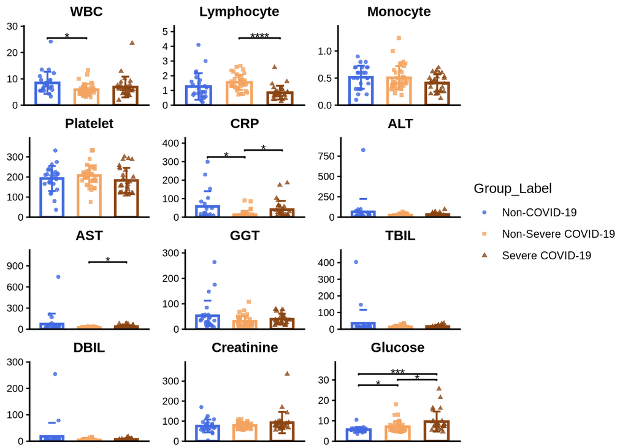

```r
# Filter for just the 3 groups we want to compare and drop empty factor levels
df_clean <- combined_clinical %>%
  filter(Group_Label %in% c("Non-COVID-19", "Non-Severe COVID-19", "Severe COVID-19")) %>%
  mutate(Group_Label = droplevels(Group_Label))

vars_of_interest <- c(
  "Age (year)", "BMI h", "WBC count, ×109/L", "Lymphocyte count, ×109/L",
  "Monocyte count, ×109/L", "Platelet count, ×109/L", "CRP i, mg/L",
  "ALT j,  U/L", "AST k, U/L", "GGT l, U/L", "TBIL m, μmol/L",
  "DBIL n, μmol/L", "Creatinine, μmol/L", "Glucose, mmol/L"
)

results_table <- map_dfr(vars_of_interest, function(var) {
  df_clean %>%
    select(Group_Label, Value = all_of(var)) %>%
    drop_na() %>%
    # Run pairwise Welch tests with BH adjustment based on the new Group_Label
    t_test(Value ~ Group_Label, var.equal = FALSE, p.adjust.method = "BH") %>%
    mutate(
      comparison = paste0("p.adj_", group1, "_vs_", group2),
      p_formatted = ifelse(p.adj < 0.001, "< 0.001", as.character(round(p.adj, 4)))
    ) %>%
    select(comparison, p_formatted) %>%
    pivot_wider(names_from = comparison, values_from = p_formatted) %>%
    mutate(Variable = var, .before = 1)
})

vars_12 <- c(
  "WBC count, ×109/L", "Lymphocyte count, ×109/L", "Monocyte count, ×109/L",
  "Platelet count, ×109/L", "CRP i, mg/L", "ALT j,  U/L",
  "AST k, U/L", "GGT l, U/L", "TBIL m, μmol/L",
  "DBIL n, μmol/L", "Creatinine, μmol/L", "Glucose, mmol/L"
)

titles_12 <- c(
  "WBC", "Lymphocyte", "Monocyte", "Platelet", "CRP", "ALT",
  "AST", "GGT", "TBIL", "DBIL", "Creatinine", "Glucose"
)

# Set up the exact comparisons based on your new factor labels
my_comparisons <- list(
  c("Non-COVID-19", "Non-Severe COVID-19"),
  c("Non-Severe COVID-19", "Severe COVID-19"),
  c("Non-COVID-19", "Severe COVID-19")
)

plot_list <- purrr::map2(vars_12, titles_12, function(var_name, plot_title) {

  temp_df <- df_clean %>%
    select(Group_Label, Value = all_of(var_name)) %>%
    drop_na()

  # Calculate Welch Stats with BH adjustment for the plot brackets
  temp_stats <- temp_df %>%
    t_test(Value ~ Group_Label,
           comparisons = my_comparisons,
           var.equal = FALSE,
           p.adjust.method = "BH") %>%
    add_significance(p.col = "p.adj") %>%
    add_xy_position(x = "Group_Label") %>%
    filter(p.adj < 0.05) # Keep only significant adjusted brackets

  # Create Plot
  ggplot(temp_df, aes(x = Group_Label, y = Value, color = Group_Label)) +
    geom_bar(stat = "summary", fun = "mean", fill = "white",
             linewidth = 1, width = 0.6, show.legend = FALSE) +
    stat_summary(fun.data = mean_sd, geom = "errorbar",
                 width = 0.2, linewidth = 0.7, show.legend = FALSE) +
    geom_jitter(aes(shape = Group_Label),
                width = 0.2, height = 0, size = 1.2, alpha = 0.8) +
    stat_pvalue_manual(temp_stats, label = "p.adj.signif",
                       tip.length = 0.01, size = 3.5, bracket.size = 0.6) +
    # Updated to match your exact new group labels
    scale_color_manual(values = c("Non-COVID-19" = "#4169E1",
                                  "Non-Severe COVID-19" = "#F4A460",
                                  "Severe COVID-19" = "#8B4513")) +
    scale_shape_manual(values = c("Non-COVID-19" = 16,
                                  "Non-Severe COVID-19" = 15,
                                  "Severe COVID-19" = 17)) +
    scale_y_continuous(limits = c(0, NA), expand = expansion(mult = c(0, 0.18))) +
    theme_classic() +
    labs(title = plot_title, x = NULL, y = NULL) +
    theme(
      plot.title = element_text(hjust = 0.5, face = "bold", size = 11),
      axis.line = element_line(color = "black", linewidth = 0.6),
      axis.text.x = element_blank(),
      axis.ticks.x = element_blank(),
      axis.text.y = element_text(size = 8)
    )
})

final_composition <- ggarrange(
  plotlist = plot_list,
  ncol = 3, nrow = 4,
  common.legend = TRUE,
  legend = "right"
)

print(final_composition)
```

Some differences have been spotted when comparing both paper and this work. All significant differences found in the paper have also been spotted in this work, although in different magnitudes (some p-value > 0.05 in the paper have been found to be p-value > 0.001 in this work, and vice versa). Also, an additional difference has been detected in the WBC between Non-COVID-19 and Non-Severe COVID-19 groups at the WBC variable.

## Exercise 2.2

Identify and handle outliers using an appropriate and well-justified method (e.g. removal, transformation, or robust statistics).

Reproduce Supplementary Figure 1 after outlier handling and discuss how and why the results change.

```r
# Variables to clean (the 12 lab parameters)
vars_to_clean <- c(
  "WBC count, ×109/L", "Lymphocyte count, ×109/L", "Monocyte count, ×109/L",
  "Platelet count, ×109/L", "CRP i, mg/L", "ALT j,  U/L",
  "AST k, U/L", "GGT l, U/L", "TBIL m, μmol/L",
  "DBIL n, μmol/L", "Creatinine, μmol/L", "Glucose, mmol/L"
)

# All variables for the table (includes Age and BMI)
vars_of_interest <- c("Age (year)", "BMI h", vars_to_clean)

# Define the function to detect outliers (1.5x IQR)
remove_outliers <- function(x) {
  q1 <- quantile(x, 0.25, na.rm = TRUE)
  q3 <- quantile(x, 0.75, na.rm = TRUE)
  iqr <- q3 - q1
  lower_bound <- q1 - 1.5 * iqr
  upper_bound <- q3 + 1.5 * iqr
  ifelse(x < lower_bound | x > upper_bound, NA, x)
}

# Prepare data
df_clean <- combined_clinical %>%
  # Keep only the 3 groups we want to plot and test
  filter(Group_Label %in% c("Non-COVID-19", "Non-Severe COVID-19", "Severe COVID-19")) %>%
  # Drop the empty factor levels (Healthy Control, COVID-19 Total)
  mutate(Group_Label = droplevels(Group_Label)) %>%
  # Group by our clean labels to calculate IQR strictly PER GROUP
  group_by(Group_Label) %>%
  # Apply outlier removal just to the 12 lab vars
  mutate(across(all_of(vars_to_clean), remove_outliers)) %>%
  ungroup()

# Check: See how many NAs (outliers) were created per variable
print("Outliers removed per variable:")
```

```
## [1] "Outliers removed per variable:"
```

```r
print(colSums(is.na(df_clean[vars_to_clean])))
```

```
##        WBC count, ×109/L Lymphocyte count, ×109/L   Monocyte count, ×109/L
##                        5                        6                        2
##   Platelet count, ×109/L              CRP i, mg/L              ALT j,  U/L
##                        5                       13                        5
##               AST k, U/L               GGT l, U/L           TBIL m, μmol/L
##                        6                        4                        6
##           DBIL n, μmol/L       Creatinine, μmol/L          Glucose, mmol/L
##                        9                        5                        9
```

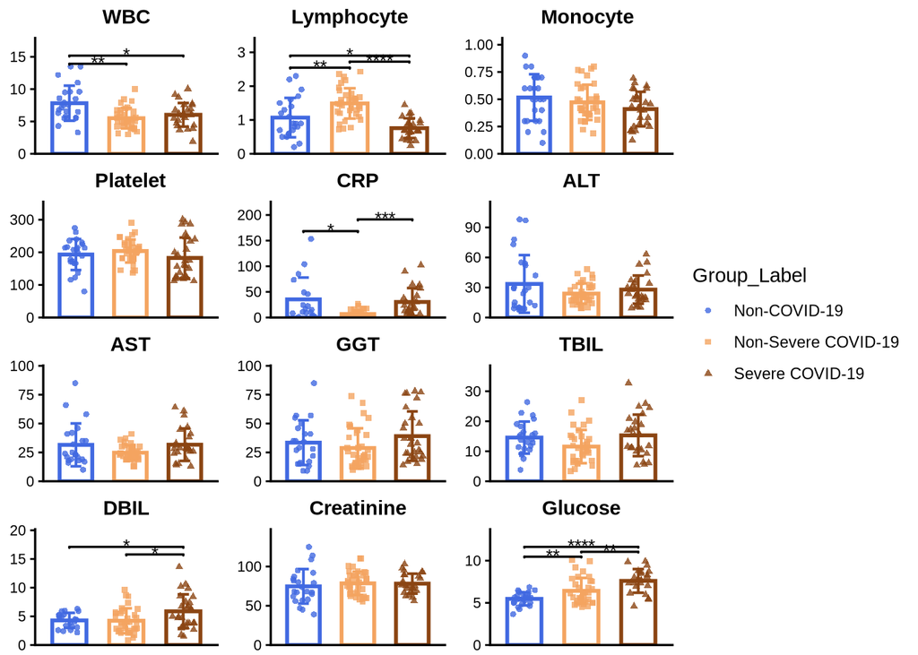

```r
# ==========================================
# compute Welch t-test using Benjamini-Hochberg correction method
results_table <- map_dfr(vars_of_interest, function(var) {
  df_clean %>%
    select(Group_Label, Value = all_of(var)) %>%
    drop_na() %>%
    t_test(Value ~ Group_Label, var.equal = FALSE, p.adjust.method = "BH") %>%
    mutate(
      comparison = paste0("p.adj_", group1, "_vs_", group2),
      p_formatted = ifelse(p.adj < 0.001, "< 0.001", as.character(round(p.adj, 4)))
    ) %>%
    select(comparison, p_formatted) %>%
    pivot_wider(names_from = comparison, values_from = p_formatted) %>%
    mutate(Variable = var, .before = 1)
})

titles_12 <- c(
  "WBC", "Lymphocyte", "Monocyte", "Platelet", "CRP", "ALT",
  "AST", "GGT", "TBIL", "DBIL", "Creatinine", "Glucose"
)

# Exact comparisons matching your preprocessed factor labels
my_comparisons <- list(
  c("Non-COVID-19", "Non-Severe COVID-19"),
  c("Non-Severe COVID-19", "Severe COVID-19"),
  c("Non-COVID-19", "Severe COVID-19")
)

plot_list <- purrr::map2(vars_to_clean, titles_12, function(var_name, plot_title) {

  temp_df <- df_clean %>%
    select(Group_Label, Value = all_of(var_name)) %>%
    drop_na()

  # Calculate Welch Stats with BH adjustment
  temp_stats <- temp_df %>%
    t_test(Value ~ Group_Label,
           comparisons = my_comparisons,
           var.equal = FALSE,
           p.adjust.method = "BH") %>%
    add_significance(p.col = "p.adj") %>%
    add_xy_position(x = "Group_Label") %>%
    filter(p.adj < 0.05) # Only include significant adjusted brackets

  # Create Plot
  ggplot(temp_df, aes(x = Group_Label, y = Value, color = Group_Label)) +
    geom_bar(stat = "summary", fun = "mean", fill = "white",
             linewidth = 1, width = 0.6, show.legend = FALSE) +
    stat_summary(fun.data = mean_sd, geom = "errorbar",
                 width = 0.2, linewidth = 0.7, show.legend = FALSE) +
    geom_jitter(aes(shape = Group_Label),
                width = 0.2, height = 0, size = 1.2, alpha = 0.8) +
    stat_pvalue_manual(temp_stats, label = "p.adj.signif",
                       tip.length = 0.01, size = 3.5, bracket.size = 0.6) +
    # Colors and shapes mapped to the labels
    scale_color_manual(values = c("Non-COVID-19" = "#4169E1",
                                  "Non-Severe COVID-19" = "#F4A460",
                                  "Severe COVID-19" = "#8B4513")) +
    scale_shape_manual(values = c("Non-COVID-19" = 16,
                                  "Non-Severe COVID-19" = 15,
                                  "Severe COVID-19" = 17)) +
    scale_y_continuous(limits = c(0, NA), expand = expansion(mult = c(0, 0.18))) +
    theme_classic() +
    labs(title = plot_title, x = NULL, y = NULL) +
    theme(
      plot.title = element_text(hjust = 0.5, face = "bold", size = 11),
      axis.line = element_line(color = "black", linewidth = 0.6),
      axis.text.x = element_blank(),
      axis.ticks.x = element_blank(),
      axis.text.y = element_text(size = 8)
    )
})

# Create the composition of plots
final_composition <- ggarrange(
  plotlist = plot_list,
  ncol = 3, nrow = 4,
  common.legend = TRUE,
  legend = "right"
)

print(final_composition)
```

When handling outliers, in general, more differences and in a higher magnitude are spotted in some variables (WBC, glucose, CRP and DBIL), while some others disappear (such as in AST count).

Given this results and the study of outliers in the violin plots, it seems that the outlier handling was remarkable to tune and clean the dataset.

Regarding the biological relevance, it seems that there are no remarkable difference between aminotransferases, while there is a decrease in the production of CRP in the case of Non-Severe COVID-19 patients. Also, they happen to have major levels of lymphocytes. This might indicate that maintaining a sufficient amount of white cells, while preserving the liver function, might act as an indicative of a healthy immune response. In this line, Severe patients present higher levels of DBIL, suggesting an increase in liver damage (Kulkarni et al., 2020).

Lastly, the increase in glucose with infection severity might be related with an immune-related metabolic response. This substrate might have been mobilized to serve as a key substrate for the immune cells given the current infection.

The WBC would follow the opposite tendency, representing major cell death levels of this cell types when an infection is occurring.